# CH6

1. Generate a data set with p = 20 features, n = 1,000 observations, and an associated quantitative response vector generated according to the model $Y = X\beta +\epsilon$, where $\beta$ has some elements that are exactly equal to zero.

```r
set.seed(627)

b <- rnorm(20)
zeroElem <- sample(20,0.2*20)
b[zeroElem] <- 0
b <- as.matrix(b)

X <- data.frame(replicate(20,rnorm(1000)))
X <- as.matrix(X)

eps <- as.matrix(rnorm(1000))
Y <- X %*% b + eps
#Y
```

2. Split your data set into a training set containing 100 observations and a test set containing 900 observations.

```r
# Split
train <- sample(1000,100)
X.train <- X[train,]
X.test <- X[-train,]
Y.train <- Y[train]
Y.test <- Y[-train]
nrow(X.train)
```

```
## [1] 100
```

```r
nrow(X.test)
```

```
## [1] 900
```

3. Perform best subset selection on the training set, and plot the training set MSE associated with the best model of each size.

```r
#?regsubsets
fit.best <- regsubsets(x = X.train, y = Y.train, nvmax = 20)
best.summary <- summary(fit.best)
# best.summary

## choosing a best model 16
minCP <- which.min(best.summary$cp)
minBIC <- which.min(best.summary$bic)
maxADJR2 <- which.max(best.summary$adjr2)
minCP
```

```
## [1] 16
```

```r
minBIC
```

```
## [1] 16
```

```r
maxADJR2
```

```
## [1] 16
```

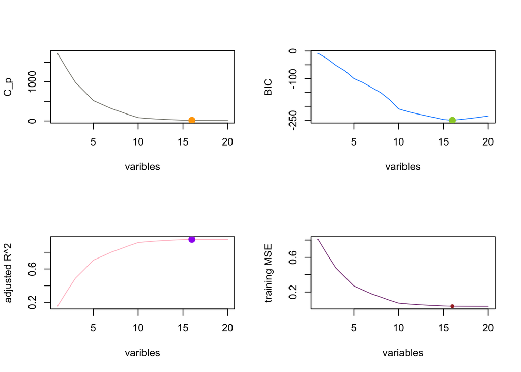

```r
par(mfrow = c(2,2))
#C_p 16
plot(best.summary$cp,xlab = "varibles", ylab = "C_p", col="ivory4" ,type = "l")
points(minCP,best.summary$cp[minCP],col="orange",cex=2,pch=20)
#BIC 16
plot(best.summary$bic,xlab = "varibles", ylab = "BIC", col="dodgerblue" ,type = "l")
points(minBIC,best.summary$bic[minBIC],col="yellowgreen",cex=2,pch=20)
#adjR^2 16
plot(best.summary$adjr2,xlab = "varibles", ylab = "adjusted R^2", col="pink" ,type = "l")
points(maxADJR2,best.summary$adjr2[maxADJR2],col="purple",cex=2,pch=20)

# training MSE
totalTrainMse <- best.summary$rss / length(X.train)
plot(totalTrainMse, xlab = "variables", ylab = "training MSE",type = "l", col = "orchid4")
points(16, totalTrainMse[16], col="brown",pch=20)
```

4. Plot the test set MSE associated with the best model of each size.

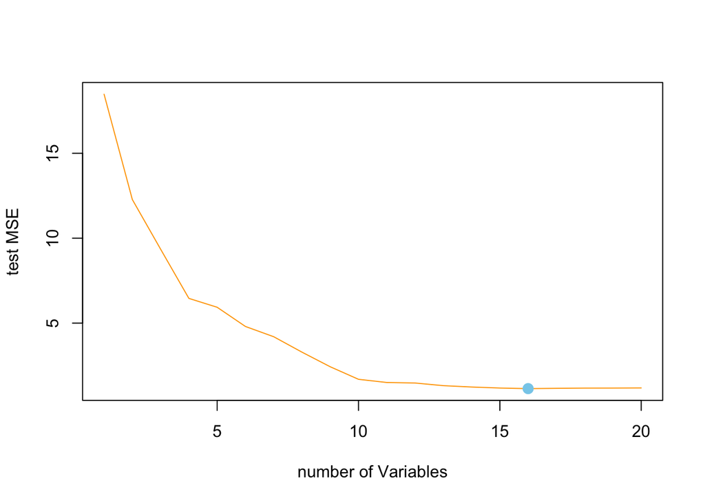

```r
# testing MSE

# pred <- predict(fit.best, X.test)
# Error in UseMethod("predict") : "predict"没有适用于"regsubsets"目标对象的方法

Xtest <- cbind("(Intercept)" = 1, X.test)  #1000*21
mse <- c()

### Select non-zero elements and do matrix multiplication ###
for (i in 1:20) {
  bestCoef <- coef(fit.best, id = i)
  yHat <- Xtest[, colnames(Xtest) %in% names(bestCoef)] %*% bestCoef  #
  mse[i] <- mean((Y.test- yHat)^2)
  # for (j in 2:21) {
  #   if(best.summary$which[i,j]){
  #     beta[j,] <- coef(fit.best, id = i)[j]
  #   }
  # }
}
MSEmin <- which.min(mse)
plot(mse, xlab = "number of Variables", ylab = "test MSE", type = "l", col="orange")
points(MSEmin, mse[MSEmin], col="skyblue", cex = 2, pch=20)
```

```r
# br <- c(rep(0,20)) #No intercept
# for (j in 2:sum(best.summary$outmat[16,]=="*")) {
#   if(best.summary$outmat[16,j]=="*"){
#     br[] <- coef(fit.best, 16)[]
#   }
# }
```

5. For which model size does the test set MSE take on its minimum value? Comment on your results. If it takes on its minimum value for a model containing only an intercept or a model containing all of the features, then play around with the way that you are generating the data in (a) until you come up with a scenario in which the test set MSE is minimized for an intermediate model size.

```r
mse
```

```
##  [1] 18.475064 12.275107  9.352488  6.455479  5.933143  4.802286  4.198367
##  [8]  3.289638  2.429437  1.690621  1.503280  1.472429  1.316698  1.236738
## [15]  1.176395  1.142329  1.159912  1.173003  1.174924  1.181785
```

```r
MSEmin
```

```
## [1] 16
```

```r
# 16th. Since MSE = Variance + Bias^2, the test MSE first decreases, MSE is minimal at 16, and then increases.
```

6. How does the model at which the test set MSE is minimized compare to the true model used to generate the data? Comment on the coefficient values.

```r
best.summary$outmat[16,]
```

```
##  X1  X2  X3  X4  X5  X6  X7  X8  X9 X10 X11 X12 X13 X14 X15 X16 X17 X18 X19 X20
## "*" "*" "*" "*" " " "*" "*" "*" " " " " "*" "*" "*" " " "*" "*" "*" "*" "*" "*"
```